# Social Media

Josephine Haag

2020-09-16

# 1 SOCIAL MEDIA

# 2 General Social Survey (GSS)

The [General Social Survey (GSS)](http://www.gss.norc.org/) gathers data on American society in order to monitor and explain trends in attitudes, behaviours, and attributes. Many trends have been tracked for decades, so one can see the evolution of attitudes, etc in American Society.

```r
gss <- read_csv(here::here("content", "blogs", "smallgss2016.csv"),
                na = c("", "Don't know",
                       "No answer", "Not applicable"))
glimpse(gss)
```

```
## Rows: 2,867
## Columns: 7
## $ emailmin <chr> "0", "30", "NA", "10", "NA", "0", "0", "NA", "0", "NA", "0",…
## $ emailhr  <chr> "12", "0", "NA", "0", "NA", "2", "40", "NA", "0", "NA", "2",…
## $ snapchat <chr> "NA", "No", "No", "NA", "Yes", "No", "NA", "Yes", "NA", "No"…
## $ instagrm <chr> "NA", "No", "No", "NA", "Yes", "Yes", "NA", "Yes", "NA", "No…
## $ twitter  <chr> "NA", "No", "No", "NA", "No", "No", "NA", "No", "NA", "No", …
## $ sex      <chr> "Male", "Male", "Male", "Female", "Female", "Female", "Male"…
## $ degree   <chr> "Bachelor", "High school", "Bachelor", "High school", "Gradu…
```

## 2.1 Instagram and Snapchat, by sex

Can we estimate the *population* proportion of Snapchat or Instagram users in 2016?

```r
gss_snap_insta <- gss %>%
  # create the new variable for snap_insta
  mutate(snap_insta = case_when(
    snapchat == "Yes" | instagrm == "Yes" ~ "Yes",
    snapchat == "No" & instagrm == "No" ~ "No",
    TRUE ~ NA_character_))

# calculate the proportion
gss_prop <- gss_snap_insta %>%
  filter(!is.na(snap_insta)) %>%
  group_by(snap_insta) %>%
  summarise(count = n()) %>%
  mutate(prop = count/sum(count))
gss_prop
```

```
## # A tibble: 2 x 3
##   snap_insta count  prop
##   <chr>      <int> <dbl>
## 1 No           858 0.625
## 2 Yes          514 0.375
```

```r
# percentile_ci
snap_insta_formula_ci <- gss_snap_insta %>%
  group_by(sex) %>%
  # using the CI formula m +- z * se
  summarize(p_hat = prop(snap_insta == "Yes"),
            count = n(),
            se = sqrt((p_hat * (1 - p_hat)) / count),
            t_critical = qt(0.975, count-1),
            margin_of_error = t_critical*se,
            lower_95 = p_hat - margin_of_error,
            upper_95 = p_hat + margin_of_error)
snap_insta_formula_ci
```

```
## # A tibble: 2 x 8
##   sex    p_hat count     se t_critical margin_of_error lower_95 upper_95
##   <chr>  <dbl> <int>  <dbl>      <dbl>           <dbl>    <dbl>    <dbl>
## 1 Female 0.419  1591 0.0124       1.96          0.0243    0.394    0.443
## 2 Male   0.318  1276 0.0130       1.96          0.0256    0.293    0.344
```

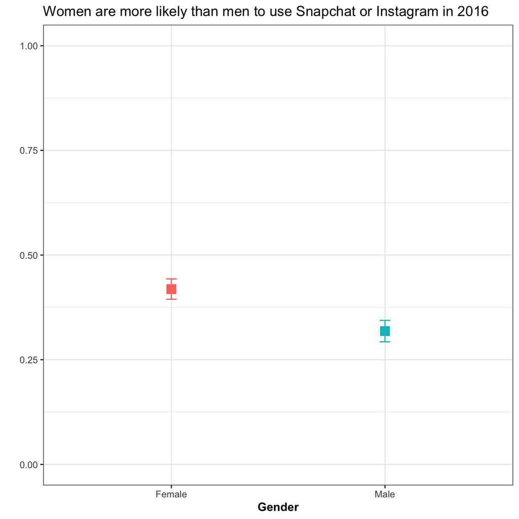

```r
# additional plot for practice
histogram_si <- ggplot(snap_insta_formula_ci,
       aes(x = sex,
           y = p_hat,
           colour = sex)) +
   geom_errorbar(aes(ymin = lower_95,
                     ymax = upper_95),
                     width = 0.05,
                     size  = 0.5) +
   geom_point(shape = 15,
              size  = 4) +
   scale_y_continuous(limits=c(0,1)) +
   theme_bw() +
   theme(axis.title   = element_text(face  = "bold")) +
   labs(x = "Gender",
     y = "",
   title = "Women are more likely than men to use Snapchat or Instagram in 2016") +
   theme(legend.position = 'none') +
   NULL
histogram_si
```

## 2.2 Twitter, by education level

Can we estimate the *population* proportion of Twitter users by education level in 2016?.

```r
# turn degree from a character variable into a factor variable
gss_factor <- gss %>%
  mutate(degree = factor(degree, order = TRUE, levels = c("Lt high school", "High school", "Junior college", "Bachelor", "Graduate")))

# create the new variable bachelor_graduate and assign values based on criteria below:
gss_degree <- gss_factor %>%
  mutate(bachelor_graduate = case_when(
    degree %in% c("Bachelor","Master") ~ "Yes",
    degree %in% c("Lt high school", "High school", "Junior college") ~ "No",
    TRUE ~ "NA"
    ))
# filter out NAs and filter for bachelor and graduates
gss_bachelor <- gss_degree %>%
  filter(bachelor_graduate == "Yes")

# calculate the proportion of `bachelor_graduate` using twitter
gss_twitter_prop <- gss_bachelor %>%
  group_by(twitter) %>%
  filter(twitter != "NA") %>%
  summarize(n = n()) %>%
  mutate(prop_t = n/sum(n))

gss_twitter_prop
```

```
## # A tibble: 2 x 3
##   twitter     n prop_t
##   <chr>   <int>  <dbl>
## 1 No        232  0.771
## 2 Yes        69  0.229
```

```r
# construct CI for `bachelor_graduate` (not) using twitter (but with the NAs in the 100 % )
twitter_formula_ci <- gss_twitter_prop %>%
  filter(twitter != "NA") %>%
   # use the CI formula m +- z * se
  summarize(twitter = twitter,
            p_hat_t = prop_t,
            # se for difference in proportions is sqrt(p(1-p)/n)
            se_t = sqrt((p_hat_t *(1-p_hat_t))/n),
            count_t = n,
            t_critical_t = qt(0.975, count_t-1),
            margin_of_error_t = t_critical_t*se_t,
            lower_95_t = p_hat_t - margin_of_error_t,
            upper_95_t = p_hat_t + margin_of_error_t)
twitter_formula_ci
```

```
## # A tibble: 2 x 8
##   twitter p_hat_t   se_t count_t t_critical_t margin_of_error… lower_95_t
##   <chr>     <dbl>  <dbl>   <int>        <dbl>            <dbl>      <dbl>
## 1 No        0.771 0.0276     232         1.97           0.0544      0.716
## 2 Yes       0.229 0.0506      69         2.00           0.101       0.128
## # … with 1 more variable: upper_95_t <dbl>
```

[figure not shown]

```r
# check if Confidence Intervals overlap
histogram_t <- ggplot(twitter_formula_ci,
       aes(x = twitter,
           y = p_hat_t,
           colour = twitter)) +
   geom_errorbar(aes(ymin = lower_95_t,
                     ymax = upper_95_t),
                     width = 0.05,
                     size  = 0.5) +
   geom_point(shape = 15,
              size  = 4) +
   scale_y_continuous(limits=c(0,1)) +
   theme_bw() +
   theme(axis.title   = element_text(face  = "bold")) +
   labs(x = "Twitter usage",
        y = "",
   title = "Twitter usage among people with a bachelor or graduate degree in 2016") +
   theme(legend.position = 'none') +
   NULL

histogram_t
```

## 2.3 Email usage

Can we estimate the *population* parameter on time spent on email weekly?

Answer: The median is a better measure than the mean for the typical amount of time Americans spend on email weekly since the mean is more sensitive to outliers than the median.

3. Using the `infer` package, calculate a 95% bootstrap confidence interval for the mean amount of time Americans spend on email weekly. Interpret this interval in context of the data, reporting its endpoints in “humanized” units (e.g. instead of 108 minutes, report 1 hr and 8 minutes). If you get a result that seems a bit odd, discuss why you think this might be the case.

Answer: The confidence interval and the mean are quite high because, as mentioned above, the mean is very sensitive to the outlier in the data set. Thus, the values are higher than one might probably expect.

4. Would you expect a 99% confidence interval to be wider or narrower than the interval you calculated above? Explain your reasoning.

Answer: A 99% confidence interval would be wider than a 95% confidence interval since you have to be more confident that the true value (in the case email minutes) falls within the interval we will need to allow more potential values within the interval. The confidence level most commonly adopted is 95%.

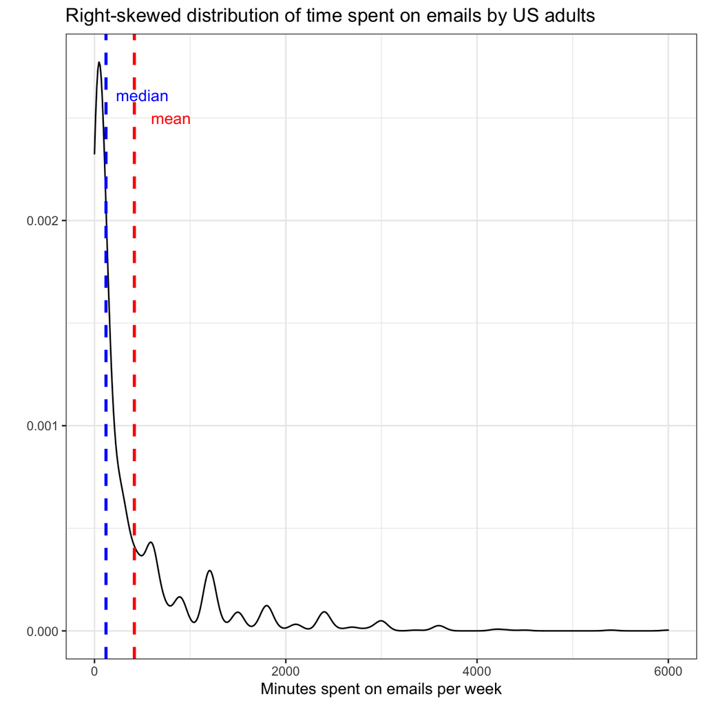

```r
# create new variable email
gss_email <- gss %>%
  filter(emailmin != "NA", emailhr != "NA") %>%
  mutate(emailmin = as.numeric(emailmin), emailhr = as.numeric(emailhr)) %>%
  mutate(email = emailhr*60 + emailmin)
# visualise the distribution
plot_email <- ggplot(gss_email,
  aes(x = email)) +
  geom_density() +
  geom_vline(aes(xintercept=mean(email, na.rm = T)),   # Ignore NA values for mean
               color="red", linetype="dashed", size=1) +
  geom_vline(aes(xintercept=median(email, na.rm = T)),   # Ignore NA values for mean
               color="blue", linetype="dashed", size=1) +
  annotate("text", x = 800, y = 0.0025, label = "mean", color="red") +
  annotate("text", x = 500, y = 0.00261, label = "median", color="blue") +
  theme_bw()+
  theme(legend.position = "none") +
  labs(
    title = "Right-skewed distribution of time spent on emails by US adults",
    x = "Minutes spent on emails per week",
    y = " ") +
  NULL
plot_email
```

```r
# calculate a 95% bootstrap confidence interval for the mean
boot_email <- gss_email %>%
  specify(response = email) %>%
  generate(reps = 1000, type = "bootstrap") %>%
  calculate(stat = "mean")

boot_email
```

```
## # A tibble: 1,000 x 2
##    replicate  stat
##        <int> <dbl>
##  1         1  394.
##  2         2  445.
##  3         3  384.
##  4         4  428.
##  5         5  407.
##  6         6  431.
##  7         7  429.
##  8         8  410.
##  9         9  404.
## 10        10  415.
## # … with 990 more rows
```

```r
# 95% CI and humanize units
percentile_ci <- boot_email %>%
  get_confidence_interval(level = 0.95, type = "percentile") %>%
  mutate(lower_ci_hum = lower_ci %/% 60 + (lower_ci %% 60)/100, upper_ci_hum = upper_ci %/% 60 + (upper_ci %% 60)/100)
percentile_ci
```

```
## # A tibble: 1 x 4
##   lower_ci upper_ci lower_ci_hum upper_ci_hum
##      <dbl>    <dbl>        <dbl>        <dbl>
## 1     384.     449.         6.24         7.29
```

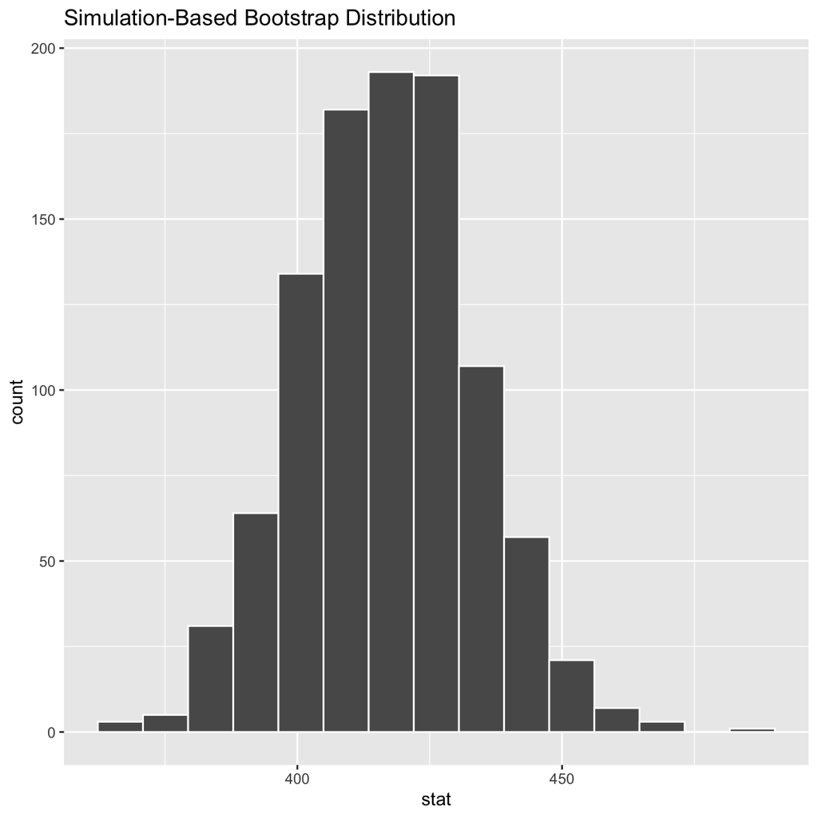

```r
visualise(boot_email)
```